# Reproducible Research Project 2

Precious Eunice Grullo

11/19/2019

## Population Health Impact and Economic Costs of Weather Events in the United States

## Synopsis

This study explores the National Oceanic and Atmospheric Administration’s (NOAA) storm database which tracks the characteristics of major weather events in the United States, including the estimates of fatalities, injuries, property damage and crop damage.

Using the dataset, this study aims to analyze the impact of the weather events to the health and economy of the population in United States. Specifically, this study enumerates the following: 1. Types of weather events that caused the highest combined number of fatalities and injuries as determinants for health effects 2. Types of weather events that caused the highest combined damage costs to properties and crops as determinants for economic costs.

## Data Processing

### Loading the needed packages.

```r
library(knitr)
library(dplyr)
library(lubridate)
```

```r
library(ggplot2)
```

### Loading the data.

The data used in this study came from a database containing data from January 1950 to 2011. These data were entered by NOAA’s National Weather Service (NWS). The dataset was downloaded from https://d396qusza40orc.cloudfront.net/repdata%2Fdata%2FStormData.csv.bz2. The description of the dataset was available in this URL, https://www.ncdc.noaa.gov/stormevents/details.jsp.

```r
if (!file.exists("stormData.csv.bz2")) {
     file<-"https://d396qusza40orc.cloudfront.net/repdata%2Fdata%2FStormData.csv.bz2"
     download.file(file, destfile="stormData.csv.bz2", method="curl")
}

#Loading the raw data file.
storm_raw <- read.csv("stormData.csv.bz2")
```

### Data transformations: Description and Justification

The structure of the dataset was analyzed.

```r
#Look at the structure of the dataset.
str(storm_raw)
```

```
## 'data.frame':    902297 obs. of  37 variables:
##  $ STATE__   : num  1 1 1 1 1 1 1 1 1 1 ...
##  $ BGN_DATE  : Factor w/ 16335 levels "1/1/1966 0:00:00",..: 6523 6523 4242 11116 2224 2224 2260 383 3980 3980 ...
##  $ BGN_TIME  : Factor w/ 3608 levels "000","0000","0001",..: 152 167 2645 1563 2524 3126 122 1563 3126 3126 ...
##  $ TIME_ZONE : Factor w/ 22 levels "ADT","AKS","AST",..: 6 6 6 6 6 6 6 6 6 6 ...
##  $ COUNTY    : num  97 3 57 89 43 77 9 123 125 57 ...
##  $ COUNTYNAME: Factor w/ 29601 levels "","5NM E OF MACKINAC BRIDGE TO PRESQUE ISLE LT MI",..: 13513 1873 4598 10592 4372 10094 1973 23873 24418 4598 ...
##  $ STATE     : Factor w/ 72 levels "AK","AL","AM",..: 2 2 2 2 2 2 2 2 2 2 ...
##  $ EVTYPE    : Factor w/ 985 levels "   HIGH SURF ADVISORY",..: 826 826 826 826 826 826 826 826 826 826 ...
##  $ BGN_RANGE : num  0 0 0 0 0 0 0 0 0 0 ...
##  $ BGN_AZI   : Factor w/ 35 levels "","  N"," NW",..: 1 1 1 1 1 1 1 1 1 1 ...
##  $ BGN_LOCATI: Factor w/ 54429 levels ""," Christiansburg",..: 1 1 1 1 1 1 1 1 1 1 ...
##  $ END_DATE  : Factor w/ 6663 levels "","1/1/1993 0:00:00",..: 1 1 1 1 1 1 1 1 1 1 ...
##  $ END_TIME  : Factor w/ 3647 levels ""," 0900CST",..: 1 1 1 1 1 1 1 1 1 1 ...
##  $ COUNTY_END: num  0 0 0 0 0 0 0 0 0 0 ...
```

[output cut: 23 more lines]

The dataset contains 902,297 observations with 37 variables. A subset of this dataset containing variables pertinent to the study questions was created. The following variables were included in the subset: 1. “BGN_DATE” - date when the weather event occurred 2. “EVTYPE” - type of weather event 3. “FATALITIES” - number of deaths that occurred directly or indirectly due to the event 4. “INJURIES” - number of injuries that occurred directly or indirectly due to the event 5. “PROPDMG” - cost of damage to property 6. “PROPDMGEXP” - exponential factor for damage to property 7. “CROPDMG” - cost of damage to crops 8. “CROPDMGEXP” - exponential factor for damage to crops

```r
#Enumeration of variable names
names(storm_raw)
```

```
##  [1] "STATE__"    "BGN_DATE"   "BGN_TIME"   "TIME_ZONE"  "COUNTY"
##  [6] "COUNTYNAME" "STATE"      "EVTYPE"     "BGN_RANGE"  "BGN_AZI"
## [11] "BGN_LOCATI" "END_DATE"   "END_TIME"   "COUNTY_END" "COUNTYENDN"
## [16] "END_RANGE"  "END_AZI"    "END_LOCATI" "LENGTH"     "WIDTH"
## [21] "F"          "MAG"        "FATALITIES" "INJURIES"   "PROPDMG"
## [26] "PROPDMGEXP" "CROPDMG"    "CROPDMGEXP" "WFO"        "STATEOFFIC"
## [31] "ZONENAMES"  "LATITUDE"   "LONGITUDE"  "LATITUDE_E" "LONGITUDE_"
## [36] "REMARKS"    "REFNUM"
```

```r
#Creation of subset containing pertinent variables
storm <- storm_raw %>% select("BGN_DATE", "EVTYPE", "FATALITIES",  "INJURIES", "PROPDMG", "PROPDMGEXP", "CROPDMG", "CROPDMGEXP")

#Looking at the structure of the subset
str(storm)
```

```
## 'data.frame':    902297 obs. of  8 variables:
##  $ BGN_DATE  : Factor w/ 16335 levels "1/1/1966 0:00:00",..: 6523 6523 4242 11116 2224 2224 2260 383 3980 3980 ...
##  $ EVTYPE    : Factor w/ 985 levels "   HIGH SURF ADVISORY",..: 826 826 826 826 826 826 826 826 826 826 ...
##  $ FATALITIES: num  0 0 0 0 0 0 0 0 1 0 ...
##  $ INJURIES  : num  15 0 2 2 2 6 1 0 14 0 ...
##  $ PROPDMG   : num  25 2.5 25 2.5 2.5 2.5 2.5 2.5 25 25 ...
##  $ PROPDMGEXP: Factor w/ 19 levels "","+","-","0",..: 16 16 16 16 16 16 16 16 16 16 ...
##  $ CROPDMG   : num  0 0 0 0 0 0 0 0 0 0 ...
##  $ CROPDMGEXP: Factor w/ 9 levels "","0","2","?",..: 1 1 1 1 1 1 1 1 1 1 ...
```

#### Data Transformation for the variable “BGN_DATE”.

The data contains records from 1950 to 2011. However, all 48 event types were recorded only from 1996 to 2011. From 1950 to 1954, only tornadoes were recorded; from 1955 to 1995, only tornado, thunderstorm wind and hail events were recorded. If the tornadoes have the most number of years recorded, there is a possibility that it would have higher health and economic damage recorded. In order to remove this measurement bias, a subset of data wherein all 48 event types were recorded (from 1996-2011) was created.

```r
#Creation of variable year
storm_date <- storm %>% mutate(date=mdy_hms(storm$BGN_DATE)) %>% mutate(year=year(date))

#Creation of subset recorded from years 1996 to 2011.
storm_df <- storm_date %>% filter(year>=1996)
str(storm_df)
```

```
## 'data.frame':    653530 obs. of  10 variables:
##  $ BGN_DATE  : Factor w/ 16335 levels "1/1/1966 0:00:00",..: 764 69 69 69 69 255 255 285 464 464 ...
##  $ EVTYPE    : Factor w/ 985 levels "   HIGH SURF ADVISORY",..: 962 826 846 846 846 241 343 846 846 846 ...
##  $ FATALITIES: num  0 0 0 0 0 0 0 0 0 0 ...
##  $ INJURIES  : num  0 0 0 0 0 0 0 0 0 0 ...
##  $ PROPDMG   : num  380 100 3 5 2 0 400 12 8 12 ...
##  $ PROPDMGEXP: Factor w/ 19 levels "","+","-","0",..: 16 16 16 16 16 1 16 16 16 16 ...
##  $ CROPDMG   : num  38 0 0 0 0 0 0 0 0 0 ...
##  $ CROPDMGEXP: Factor w/ 9 levels "","0","2","?",..: 6 1 1 1 1 1 1 1 1 1 ...
##  $ date      : POSIXct, format: "1996-01-06" "1996-01-11" ...
##  $ year      : num  1996 1996 1996 1996 1996 ...
```

#### Data Transformation for the variable “EVTYPE”.

The unique values under the variable “EVTYPE” was examined.

```r
unique(storm$EVTYPE)
```

```
##   [1] TORNADO                        TSTM WIND
##   [3] HAIL                           FREEZING RAIN
##   [5] SNOW                           ICE STORM/FLASH FLOOD
##   [7] SNOW/ICE                       WINTER STORM
##   [9] HURRICANE OPAL/HIGH WINDS      THUNDERSTORM WINDS
##  [11] RECORD COLD                    HURRICANE ERIN
##  [13] HURRICANE OPAL                 HEAVY RAIN
##  [15] LIGHTNING                      THUNDERSTORM WIND
##  [17] DENSE FOG                      RIP CURRENT
##  [19] THUNDERSTORM WINS              FLASH FLOOD
##  [21] FLASH FLOODING                 HIGH WINDS
##  [23] FUNNEL CLOUD                   TORNADO F0
##  [25] THUNDERSTORM WINDS LIGHTNING   THUNDERSTORM WINDS/HAIL
##  [27] HEAT                           WIND
##  [29] LIGHTING                       HEAVY RAINS
```

[output cut: 479 more lines]

```r
# Data cleaning
storm_df$EVTYPE <- toupper(storm_df$EVTYPE)
storm_df$EVTYPE[grep("SMOKE",storm_df$EVTYPE)] <- "SMOKE"
storm_df$EVTYPE[grep("WET",storm_df$EVTYPE)] <- "WET"
storm_df$EVTYPE[grep("AVALAN",storm_df$EVTYPE)] <- "AVALANCHE"
storm_df$EVTYPE[grep("RAIN",storm_df$EVTYPE)] <- "HEAVY RAIN"
storm_df$EVTYPE[grep("COLD|COOL|HYPOTHERMIA|FREEZE|FROST",storm_df$EVTYPE)] <- "HYPOTHERMIA"
storm_df$EVTYPE[grep("DRY|DRIEST",storm_df$EVTYPE)] <- "DRY"
storm_df$EVTYPE[grep("FLOOD|FLDG|FLD|URBAN|FLOOO|FLOYD|DAM",storm_df$EVTYPE)] <- "FLOOD"
storm_df$EVTYPE[grep("HAIL",storm_df$EVTYPE)] <- "HAIL"
storm_df$EVTYPE[grep("FREEZING",storm_df$EVTYPE)] <- "FREEZING RAIN"
storm_df$EVTYPE[grep("BLIZZARD|WINTER",storm_df$EVTYPE)] <- "BLIZZARD"
storm_df$EVTYPE[grep("HYPERTHERMIA|WARM",storm_df$EVTYPE)] <- "HYPERTHERMIA"
storm_df$EVTYPE[grep("ICE|ICY",storm_df$EVTYPE)] <- "ICE"
storm_df$EVTYPE[grep("HIGH WIND",storm_df$EVTYPE)] <- "HIGH WIND"
storm_df$EVTYPE[grep("HURRICANE|TYPHOON",storm_df$EVTYPE)] <- "HURRICANE"
storm_df$EVTYPE[grep("SURF",storm_df$EVTYPE)] <- "SURF"
storm_df$EVTYPE[grep("PRECIP",storm_df$EVTYPE)] <- "PRECIPITATION"
storm_df$EVTYPE[grep("SNOW",storm_df$EVTYPE)] <- "SNOW"
storm_df$EVTYPE[grep("TROP",storm_df$EVTYPE)] <- "TROPICAL STORM"
storm_df$EVTYPE[grep("THUNDER|TSTM",storm_df$EVTYPE)] <- "THUNDER STORM"
storm_df$EVTYPE[grep("LIGHTN|LIGHTI|LIGNT",storm_df$EVTYPE)] <- "LIGHTNING"
storm_df$EVTYPE[grep("WIND|WND",storm_df$EVTYPE)] <- "WIND"
storm_df$EVTYPE[grep("TORN|FUNNEL",storm_df$EVTYPE)] <- "TORNADO"
storm_df$EVTYPE[grep("FIRE",storm_df$EVTYPE)] <- "WILDFIRE"
storm_df$EVTYPE[grep("TEMPERATURE",storm_df$EVTYPE)] <- "RECORD TEMPERATURE"
storm_df$EVTYPE[grep("DUST",storm_df$EVTYPE)] <- "DUSTSTORM"
storm_df$EVTYPE[grep("SURGE",storm_df$EVTYPE)] <- "STORM SURGE"
storm_df$EVTYPE[grep("SPOUT",storm_df$EVTYPE)]  <- "WATERSPOUT"
storm_df$EVTYPE[grep("HEAT|HOT|HIGH TEMP",storm_df$EVTYPE)] <- "HEATWAVE"
storm_df$EVTYPE[grep("SWELL|SEA|TIDE",storm_df$EVTYPE)] <- "HIGH SEAS"
storm_df$EVTYPE[grep("COASTAL",storm_df$EVTYPE)] <- "COASTAL ACCIDENT"
storm_df$EVTYPE[grep("RIP",storm_df$EVTYPE)] <- "RIPTIDE"
storm_df$EVTYPE[grep("FOG|VOG",storm_df$EVTYPE)]  <- "FOG"
storm_df$EVTYPE[grep("SLIDE|SLUMP",storm_df$EVTYPE)]  <- "LANDSLIDE"
storm_df$EVTYPE[grep("VOLCAN",storm_df$EVTYPE)] <- "VOLCANO"
storm_df$EVTYPE[grep("SUMMARY|MONTHLY",storm_df$EVTYPE)] <- "SUMMARY"
storm_df$EVTYPE[grep("NO",storm_df$EVTYPE)] <- "NONE"

unique(storm_df$EVTYPE)
```

```
##  [1] "BLIZZARD"            "TORNADO"             "THUNDER STORM"
##  [4] "HAIL"                "WIND"                "HEAVY RAIN"
##  [7] "FLOOD"               "HYPOTHERMIA"         "HEATWAVE"
## [10] "LIGHTNING"           "WATERSPOUT"          "RIPTIDE"
## [13] "NONE"                "OTHER"               "DRY"
## [16] "RECORD TEMPERATURE"  "WILDFIRE"            "ICE"
## [19] "STORM SURGE"         "DUSTSTORM"           "DROUGHT"
## [22] "FOG"                 "SURF"                "MARINE ACCIDENT"
## [25] "AVALANCHE"           "TROPICAL STORM"      "COASTAL ACCIDENT"
## [28] "WET"                 "HURRICANE"           "BEACH EROSION"
## [31] "WINTRY MIX"          "LANDSLIDE"           "HYPERTHERMIA"
## [34] "GLAZE"               "FREEZING RAIN"       "PRECIPITATION"
## [37] "DOWNBURST"           "SUMMARY"             "METRO STORM, MAY 26"
## [40] "MICROBURST"          "HIGH SEAS"           "RECORD HIGH"
## [43] "SEICHE"              "SLEET"               "WALL CLOUD"
## [46] "HIGH WATER"          "RED FLAG CRITERIA"   "SMOKE"
## [49] "ROGUE WAVE"          "DROWNING"            "SLEET STORM"
## [52] "TSUNAMI"
```

Two of the levels are not event types - “NONE” which is defined as no weather event and “SUMMARY” which is defined as monthly summaries. A subset excluding these two are created.

```r
#Creation of subset containing 48 weather events
storm_df0 <- filter(storm_df, !EVTYPE%in%c("NONE","SUMMARY"))
unique(storm_df0$EVTYPE)
```

```
##  [1] "BLIZZARD"            "TORNADO"             "THUNDER STORM"
##  [4] "HAIL"                "WIND"                "HEAVY RAIN"
##  [7] "FLOOD"               "HYPOTHERMIA"         "HEATWAVE"
## [10] "LIGHTNING"           "WATERSPOUT"          "RIPTIDE"
## [13] "OTHER"               "DRY"                 "RECORD TEMPERATURE"
## [16] "WILDFIRE"            "ICE"                 "STORM SURGE"
## [19] "DUSTSTORM"           "DROUGHT"             "FOG"
## [22] "SURF"                "MARINE ACCIDENT"     "AVALANCHE"
## [25] "TROPICAL STORM"      "COASTAL ACCIDENT"    "WET"
## [28] "HURRICANE"           "BEACH EROSION"       "WINTRY MIX"
## [31] "LANDSLIDE"           "HYPERTHERMIA"        "GLAZE"
## [34] "FREEZING RAIN"       "PRECIPITATION"       "DOWNBURST"
## [37] "METRO STORM, MAY 26" "MICROBURST"          "HIGH SEAS"
## [40] "RECORD HIGH"         "SEICHE"              "SLEET"
## [43] "WALL CLOUD"          "HIGH WATER"          "RED FLAG CRITERIA"
## [46] "SMOKE"               "ROGUE WAVE"          "DROWNING"
## [49] "SLEET STORM"         "TSUNAMI"
```

#### Data Transformation for the variables “FATALITIES” and “INJURIES”.

The structure and summary of the variables “FATALITIES” and “INJURIES” were examined.

```r
#Looking at the structure and summary of the variables "FATALITIES" and "INJURIES"
str(storm_df0$FATALITIES)
```

```
##  num [1:637952] 0 0 0 0 0 0 0 0 0 0 ...
```

```r
summary(storm_df0$FATALITIES)
```

```
##      Min.   1st Qu.    Median      Mean   3rd Qu.      Max.
##   0.00000   0.00000   0.00000   0.01351   0.00000 158.00000
```

```r
str(storm_df0$INJURIES)
```

```
##  num [1:637952] 0 0 0 0 0 0 0 0 0 0 ...
```

```r
summary(storm_df0$INJURIES)
```

```
##     Min.  1st Qu.   Median     Mean  3rd Qu.     Max.
## 0.00e+00 0.00e+00 0.00e+00 8.97e-02 0.00e+00 1.15e+03
```

To answer the first question, the two health-related variables must be combined, creating a new variable, “HEALTH”. This would represent the total harm to the population health caused by the specific weather event.

```r
#Creation of the variable "HEALTH"
storm_df1 <- storm_df0 %>% mutate("HEALTH"= storm_df0$FATALITIES+ storm_df0$INJURIES)
str(storm_df1$HEALTH)
```

```
##  num [1:637952] 0 0 0 0 0 0 0 0 0 0 ...
```

```r
summary(storm_df1$HEALTH)
```

```
##      Min.   1st Qu.    Median      Mean   3rd Qu.      Max.
##    0.0000    0.0000    0.0000    0.1032    0.0000 1308.0000
```

#### Data Transformation for the variables “PROPDMG” and “PROPDMGEXP”.

The structure of the variables “PROPDMG” and “PROPDMGEXP” were examined.

```r
#Looking at the structure of the variables "PROPDMG" and "PROPDMGEXP"
str(storm_df1$PROPDMG)
```

```
##  num [1:637952] 380 100 3 5 2 0 400 12 8 12 ...
```

```r
summary(storm_df1$PROPDMG)
```

```
##    Min. 1st Qu.  Median    Mean 3rd Qu.    Max.
##    0.00    0.00    0.00   11.81    1.50 5000.00
```

```r
str(storm_df1$PROPDMGEXP)
```

```
##  Factor w/ 19 levels "","+","-","0",..: 16 16 16 16 16 1 16 16 16 16 ...
```

The unique values under the variable “PROPDMGEXP” was examined.

```r
unique(storm_df1$PROPDMGEXP)
```

```
## [1] K   M B 0
## Levels:  + - 0 1 2 3 4 5 6 7 8 ? B H K M h m
```

The values under the variable “PROPDMGEXP” was converted into numeric equivalent.

```r
#Data cleaning
storm_df1$PROPDMGEXP <- toupper(storm_df1$PROPDMGEXP)
storm_df1$PROP_EXP[(storm_df1$PROPDMGEXP == "")] <- 10^0
storm_df1$PROP_EXP[(storm_df1$PROPDMGEXP == "0")] <- 10^0
storm_df1$PROP_EXP[(storm_df1$PROPDMGEXP == "+")] <- 10^0
storm_df1$PROP_EXP[(storm_df1$PROPDMGEXP == "?")] <- 10^0
storm_df1$PROP_EXP[(storm_df1$PROPDMGEXP == "-")] <- 10^0
storm_df1$PROP_EXP[(storm_df1$PROPDMGEXP == "1")] <- 10^1
storm_df1$PROP_EXP[(storm_df1$PROPDMGEXP == "2")] <- 10^2
storm_df1$PROP_EXP[(storm_df1$PROPDMGEXP == "H")] <- 10^2
storm_df1$PROP_EXP[(storm_df1$PROPDMGEXP == "K")] <- 10^3
storm_df1$PROP_EXP[(storm_df1$PROPDMGEXP == "3")] <- 10^3
storm_df1$PROP_EXP[(storm_df1$PROPDMGEXP == "4")] <- 10^4
storm_df1$PROP_EXP[(storm_df1$PROPDMGEXP == "5")] <- 10^5
storm_df1$PROP_EXP[(storm_df1$PROPDMGEXP == "6")] <- 10^6
storm_df1$PROP_EXP[(storm_df1$PROPDMGEXP == "M")] <- 10^6
storm_df1$PROP_EXP[(storm_df1$PROPDMGEXP == "7")] <- 10^7
storm_df1$PROP_EXP[(storm_df1$PROPDMGEXP == "8")] <- 10^8
storm_df1$PROP_EXP[(storm_df1$PROPDMGEXP == "B")] <- 10^9

str(storm_df1$PROP_EXP)
```

```
##  num [1:637952] 1000 1000 1000 1000 1000 1 1000 1000 1000 1000 ...
```

```r
unique(storm_df1$PROP_EXP)
```

```
## [1] 1e+03 1e+00 1e+06 1e+09
```

The variables “PROPDMG” and “PROP_EXP” were multiplied, creating a variable, “PROPCOST”. This would represent the total cost of the property damaged by the weather event.

```r
#Creation of the variable "PROPCOST"
storm_df1 <- storm_df1 %>% mutate("PROPCOST"= storm_df1$PROPDMG*storm_df1$PROP_EXP)
```

#### Data Transformation for the variable “CROPDMG” “CROPDMGEXP”.

The structure of the variables “CROPDMG” and “CROPDMGEXP” were examined.

```r
#Looking at the structure of the variables "CROPDMG" and "CROPDMGEXP"
str(storm_df1$CROPDMG)
```

```
##  num [1:637952] 38 0 0 0 0 0 0 0 0 0 ...
```

```r
summary(storm_df1$CROPDMG)
```

```
##    Min. 1st Qu.  Median    Mean 3rd Qu.    Max.
##   0.000   0.000   0.000   1.881   0.000 990.000
```

```r
str(storm_df1$CROPDMGEXP)
```

```
##  Factor w/ 9 levels "","0","2","?",..: 6 1 1 1 1 1 1 1 1 1 ...
```

The unique values under the variable “PROPDMGEXP” was examined.

```r
unique(storm_df1$CROPDMGEXP)
```

```
## [1] K   M B
## Levels:  0 2 ? B K M k m
```

The values under the variable “PROPDMGEXP” was converted into numeric equivalent.

```r
#Data cleaning
storm_df1$CROPDMGEXP <- toupper(storm_df1$CROPDMGEXP)
storm_df1$CROP_EXP[(storm_df1$CROPDMGEXP == "")] <- 10^0
storm_df1$CROP_EXP[(storm_df1$CROPDMGEXP == "0")] <- 10^0
storm_df1$CROP_EXP[(storm_df1$CROPDMGEXP == "?")] <- 10^0
storm_df1$CROP_EXP[(storm_df1$CROPDMGEXP == "2")] <- 10^2
storm_df1$CROP_EXP[(storm_df1$CROPDMGEXP == "K")] <- 10^3
storm_df1$CROP_EXP[(storm_df1$CROPDMGEXP == "M")] <- 10^6
storm_df1$CROP_EXP[(storm_df1$CROPDMGEXP == "B")] <- 10^9

str(storm_df1$CROP_EXP)
```

```
##  num [1:637952] 1000 1 1 1 1 1 1 1 1 1 ...
```

```r
unique(storm_df1$CROP_EXP)
```

```
## [1] 1e+03 1e+00 1e+06 1e+09
```

The variables “CROPDMG” and “CROP_EXP” were multiplied, creating a variable, “CROPCOST”. This would represent the total cost of the crops damaged by the weather event.

```r
#Creation of the variable "CROPCOST"
storm_df1 <- storm_df1 %>% mutate("CROPCOST"= storm_df1$CROPDMG*storm_df1$CROP_EXP)
```

To answer the second question, the two economic-related variables were combined, creating a new variable, “ECONOMY”. This would represent the total economic cost caused by the specific weather event.

```r
#Creation of the variable "ECONOMY"
storm_df1 <- storm_df1 %>% mutate("ECONOMY"=storm_df1$PROPCOST+storm_df1$CROPCOST)
```

## Results

### Damage to Health

To show which weather event caused the most harm to the population health, the total health damage represented by the variable “HEALTH” was determined per weather event. Figure 1 summarizes the ten weather events with the highest total number of fatalities and injuries.

```r
#Creation of Figure 1 showing the Top 10 Most Harmful Weather Events to Health
health_cost <- storm_df1 %>% group_by(EVTYPE) %>% summarise(total_health=sum(HEALTH)) %>% arrange(desc(total_health))

health_cost[1,]
```

```
## # A tibble: 1 x 2
##   EVTYPE  total_health
##   <chr>          <dbl>
## 1 TORNADO        22179
```

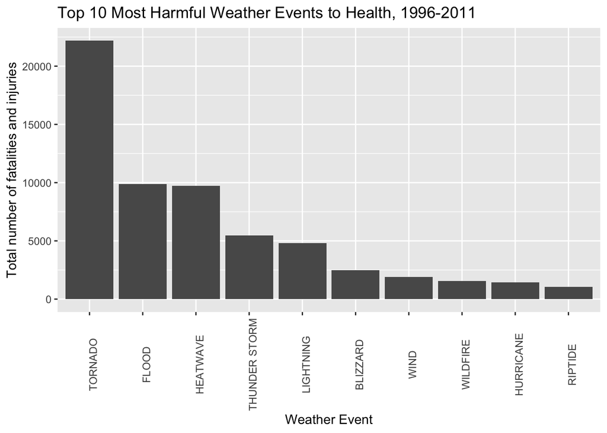

```r
fig1 <- ggplot(health_cost[1:10,], aes(x=reorder(EVTYPE,-total_health), y=health_cost$total_health[1:10])) + geom_col() + ggtitle("Top 10 Most Harmful Weather Events to Health, 1996-2011") + xlab("Weather Event") + ylab("Total number of fatalities and injuries") + theme(axis.text.x=element_text(angle=90))

fig1
```

Figure 1 shows that the weather event that is most harmful to population health is tornado. It caused the 22,179 combined fatalities and injuries accross the United States, from 1996-2011. Tornado is followed by flood and heatwave as the second and third most harmful to population health, respectively.

### Damage to economy

```r
#Creation of Figure 2 showing the Top 10 Most Damaging Weather Events to Economy
economy_cost <- storm_df1 %>% group_by(EVTYPE) %>% summarise(total_economy=sum(ECONOMY)) %>% arrange(desc(total_economy))

economy_cost[1,]
```

```
## # A tibble: 1 x 2
##   EVTYPE total_economy
##   <chr>          <dbl>
## 1 FLOOD   166114922870
```

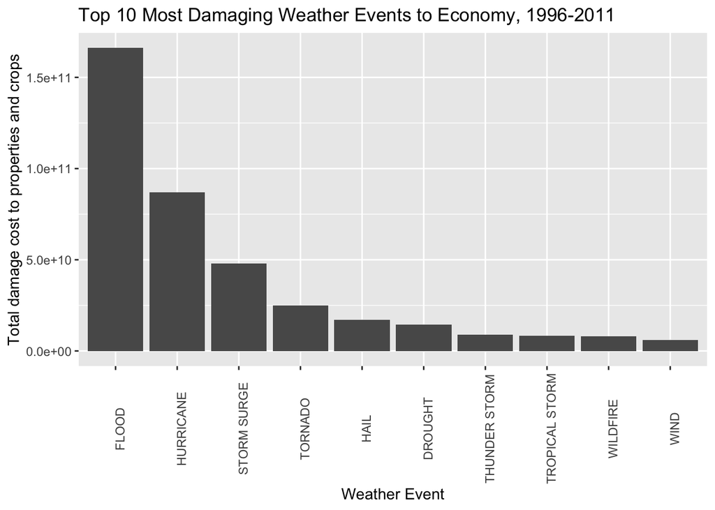

```r
fig2 <- ggplot(economy_cost[1:10,], aes(x=reorder(EVTYPE,-total_economy), y=economy_cost$total_economy[1:10])) + geom_col() + ggtitle("Top 10 Most Damaging Weather Events to Economy, 1996-2011") + xlab("Weather Event") + ylab("Total damage cost to properties and crops") + theme(axis.text.x=element_text(angle=90))

fig2
```

## Analysis

### Question 1. Which types of events are most harmful to population health?

Tornado is the most harmful to population health. It is followed by flood and heatwave.

### Question 2. Which types of events have the greatest economic consequences?

Flood caused the highest cost of economic damage across the United States from 1996-2011. It is followed by hurricane and storm surge.

## Conclusion

Tornadoes caused the greatest harm to health and flood caused the greatest economic consequences. Given that there are many other weather events occuring, policies focusing on the hazard reduction of tornadoes and flood should be prioritized.